# Self-Driving Car Engineer Nanodegree

## Project: Build a Traffic Sign Recognition Classifier

In this notebook, a template is provided for you to implement your functionality in stages, which is required to successfully complete this project. If additional code is required that cannot be included in the notebook, be sure that the Python code is successfully imported and included in your submission if necessary.

In addition to implementing code, there is a writeup to complete. The writeup should be completed in a separate file, which can be either a markdown file or a pdf document. There is a [write up template](https://github.com/udacity/CarND-Traffic-Sign-Classifier-Project/blob/master/writeup_template.md) that can be used to guide the writing process. Completing the code template and writeup template will cover all of the [rubric points](https://review.udacity.com/#!/rubrics/481/view) for this project.

The [rubric](https://review.udacity.com/#!/rubrics/481/view) contains "Stand Out Suggestions" for enhancing the project beyond the minimum requirements. The stand out suggestions are optional. If you decide to pursue the "stand out suggestions", you can include the code in this Ipython notebook and also discuss the results in the writeup file.

> **Note:** Code and Markdown cells can be executed using the **Shift + Enter** keyboard shortcut. In addition, Markdown cells can be edited by typically double-clicking the cell to enter edit mode.

## Step 0: Load The Data

The datasets for this project are provided by the `traffic-signs-data.zip` file. Training, Validation, and Testing data is already packaged separately.

### Step 0.1: Import everything

```python
# Data exploration visualization code goes here.
# Feel free to use as many code cells as needed.
import matplotlib.pyplot as plt
import matplotlib.gridspec as gridspec
import matplotlib.image as mpimg
import numpy as np
import random
import pickle
import csv
import cv2
import glob
import tensorflow as tf
from tensorflow.contrib.layers import flatten
from sklearn.utils import shuffle
from os.path import isfile, isdir

# Visualizations will be shown in the notebook.
%matplotlib inline

# Reset to Matplotlib defaults
plt.rcdefaults()
```

### Step 0.2: Load Training, Validation, and Testing Data using Pickle

```python
# Load pickled data
# TODO: Fill this in based on where you saved the training and testing data

training_file = 'train.p'
validation_file = 'valid.p'
testing_file = 'test.p'

with open(training_file, mode='rb') as f:
    train = pickle.load(f)
with open(validation_file, mode='rb') as f:
    valid = pickle.load(f)
with open(testing_file, mode='rb') as f:
    test = pickle.load(f)

X_train, y_train = train['features'], train['labels']
X_valid, y_valid = valid['features'], valid['labels']
X_test, y_test = test['features'], test['labels']
```

## Step 1: Dataset Summary & Exploration

The pickled data is a dictionary with 4 key/value pairs:

- `'features'` is a 4D array containing raw pixel data of the traffic sign images, (num examples, width, height, channels).
- `'labels'` is a 1D array containing the label/class id of the traffic sign. The file `signnames.csv` contains id -> name mappings for each id.
- `'sizes'` is a list containing tuples, (width, height) representing the original width and height the image.
- `'coords'` is a list containing tuples, (x1, y1, x2, y2) representing coordinates of a bounding box around the sign in the image. **THESE COORDINATES ASSUME THE ORIGINAL IMAGE. THE PICKLED DATA CONTAINS RESIZED VERSIONS (32 by 32) OF THESE IMAGES**

Complete the basic data summary below. Use python, numpy and/or pandas methods to calculate the data summary rather than hard coding the results. For example, the [pandas shape method](http://pandas.pydata.org/pandas-docs/stable/generated/pandas.DataFrame.shape.html) might be useful for calculating some of the summary results.

### Step 1.1: Provide a Basic Summary of the Data Set Using Python, Numpy and/or Pandas

```python
### Replace each question mark with the appropriate value.
### Use python, pandas or numpy methods rather than hard coding the results

# TODO: Number of training examples
assert (X_train.shape[0] == y_train.shape[0]), \
        'Number of features and labels do not match!'
n_train = X_train.shape[0]

# TODO: Number of validation examples
assert (X_valid.shape[0] == y_valid.shape[0]), \
        'Number of features and labels do not match!'
n_validation = X_valid.shape[0]

# TODO: Number of testing examples.
assert (X_test.shape[0] == y_test.shape[0]), \
        'Number of features and labels do not match!'
n_test = X_test.shape[0]

# TODO: What's the shape of an traffic sign image?
assert (X_train[0].shape == X_valid[0].shape == X_test[0].shape), \
        'Shape of the image is different among data sets!'
image_shape = X_train[0].shape

# TODO: How many unique classes/labels there are in the dataset.
assert (len(set(y_train)) == len(set(y_valid)) == len(set(y_test))), \
        'Number of classes is different among the data sets!'
n_classes = len(set(y_train))

print("Number of training examples =", n_train)
print("Number of testing examples =", n_test)
print("Image data shape =", image_shape)
print("Number of classes =", n_classes)
```

```
Number of training examples = 34799
Number of testing examples = 12630
Image data shape = (32, 32, 3)
Number of classes = 43
```

### Step 1.2: Include an exploratory visualization of the dataset

Visualize the German Traffic Signs Dataset using the pickled file(s). This is open ended, suggestions include: plotting traffic sign images, plotting the count of each sign, etc.

The [Matplotlib](http://matplotlib.org/) [examples](http://matplotlib.org/examples/index.html) and [gallery](http://matplotlib.org/gallery.html) pages are a great resource for doing visualizations in Python.

**NOTE:** It's recommended you start with something simple first. If you wish to do more, come back to it after you've completed the rest of the sections. It can be interesting to look at the distribution of classes in the training, validation and test set. Is the distribution the same? Are there more examples of some classes than others?

#### Step 1.2.1: Some plotting and other helper functions

```python
def plot_images(images, grid_size, fig_size, fig_spacing=(0.01, 0.01)):
    gs = gridspec.GridSpec(grid_size[0], grid_size[1])
    gs.update(wspace=fig_spacing[0], hspace=fig_spacing[1])
    plt.figure(figsize=fig_size)

    for i in range(len(images)):
        plt.subplot(gs[i])
        image = images[i].squeeze()
        if len(image.shape) == 2:
            plt.imshow(image, cmap='gray')
        else:
            plt.imshow(image)
        plt.axis('off')

    plt.show()
```

```python
def plot_class_id_distribution(y_data, x_label, y_label, title, color='blue'):
    counts = np.bincount(y_data)

    fig, ax = plt.subplots()

    ax.bar(np.arange(len(counts)), counts, align='center', color=color)
    ax.set_xlabel(x_label)
    ax.set_ylabel(y_label)
    ax.set_title(title)

    # plt.bar(np.arange(n_classes), counts)
    plt.show()

    avg = int(np.mean(counts))
    min_count = np.amin(counts)
    max_count = np.amax(counts)
    total = len(y_data)

    print('Mean: {}, Min: {}, Max: {}, Total: {}'.format(avg, min_count,
                                                         max_count, total))
```

```python
def plot_random_image(X_data, y_data, label_dict):

    index = np.random.randint(len(X_data))
    image = X_data[index].squeeze()

    class_id = str(y_train[index])
    print('label: {0} - {1}'.format(class_id, label_dict[class_id]))

    plt.figure(figsize=(2, 2))

    if len(image.shape) == 2:
        plt.imshow(image, cmap='gray')
    else:
        plt.imshow(image)

    plt.axis('off')

    plt.show()

    return index
```

```python
def load_label_dict(labels_file):

    with open(labels_file) as csvfile:
        reader = csv.DictReader(csvfile)
        label_names = {row['ClassId']:row['SignName'] for row in reader}

    return label_names
```

#### Step 1.2.2: Exploring Data

##### **Step 1.2.2.1: Pick a Random Image to Look at**

```
Random image from the Training set
label: 11 - Right-of-way at the next intersection
```

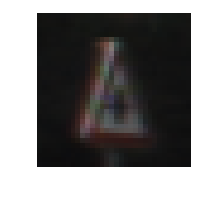

```python
### Data exploration visualization code goes here.
### Feel free to use as many code cells as needed.
# Visualizations will be shown in the notebook.

signnames = load_label_dict('signnames.csv')

# Plot a random image
print('Random image from the Training set')
_ = plot_random_image(X_train, y_train, signnames)
```

##### **Step 1.2.2.2: Look at the First 100 Images of the Training Set**

```
 First 100 images from the Training set
```

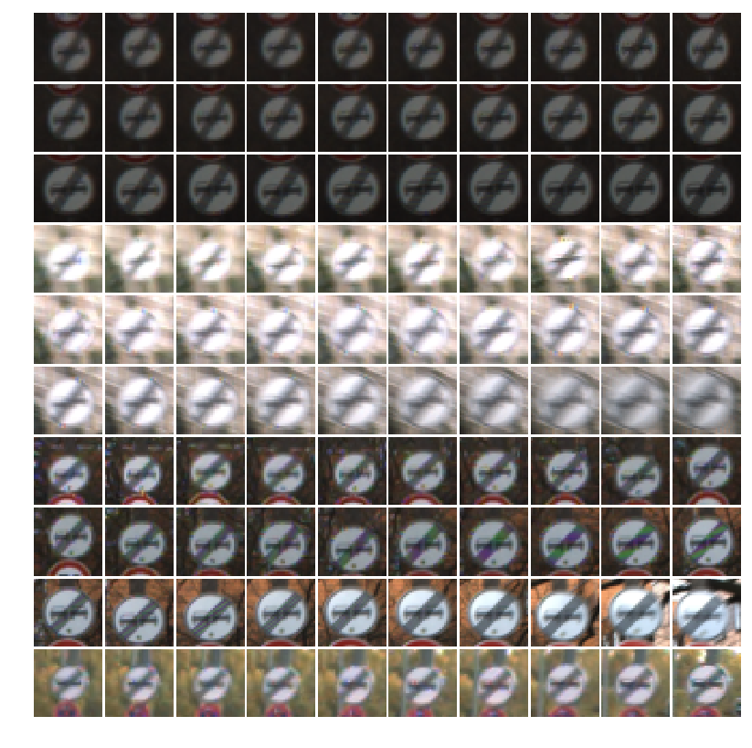

```python
# Plot 1st 100 images in training set
print(' First 100 images from the Training set')
plot_images(X_train[:100], (10, 10), (10, 10), fig_spacing=(0.02, 0.04))
```

##### **Step 1.2.2.3: Look at the First 100 Images of the Validation Set**

```
 First 100 images from the Validation set
```

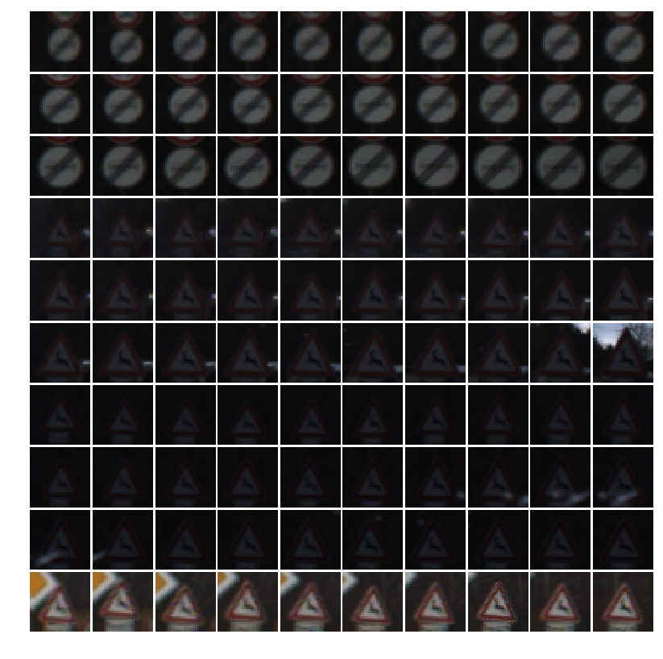

```python
# Plot 1st 100 images in validation set
print(' First 100 images from the Validation set')
plot_images(X_valid[:100], (10, 10), (10, 10), fig_spacing=(0.02, 0.04))
```

##### **Step 1.2.2.4: Observe the Distribution of Classes in the Training Set**

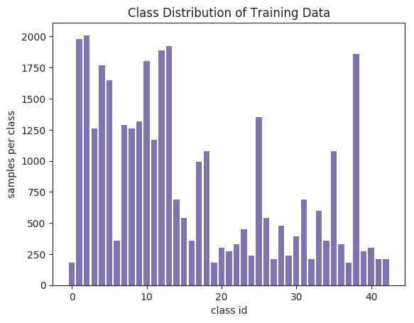

```
Mean: 809, Min: 180, Max: 2010, Total: 34799
```

```python
## make a histogram of features and labels in the training set
x_label = 'class id'
y_label = 'samples per class'
title = 'Class Distribution of Training Data'
plot_class_id_distribution(y_train, x_label, y_label, title, color='m')
```

##### **Step 1.2.2.5: Observe the Distribution of Classes in the Validation Set**

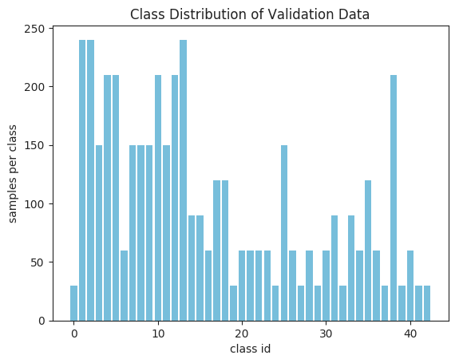

```
Mean: 102, Min: 30, Max: 240, Total: 4410
```

```python
## make a histogram of features and labels in the training set
title = 'Class Distribution of Validation Data'
plot_class_id_distribution(y_valid, x_label, y_label, title, color='c')
```

#### Step 1.2.3: Data Exploration Summary

- Printed a random image from the training set and the output is as expected. The class id and the traffic sign are matching.
- Printing the first 100 images from training and validation sets revealed that the images were all in sorted order. Shuffling is required.
- The histograms of `y_train` and `y_valid` show that the data is spread across the classes non-uniformly. Data augmentation will help the accuracy.
- The distribution of data is proportional between the training and valid sets. So, the validation accuracy may not suffer a lot because of this.
- Did not use the features `'sizes'` and `'coords'`.

## Step 2: Design and Test a Model Architecture

Design and implement a deep learning model that learns to recognize traffic signs. Train and test your model on the [German Traffic Sign Dataset](http://benchmark.ini.rub.de/?section=gtsrb&subsection=dataset).

The LeNet-5 implementation shown in the classroom at the end of the CNN lesson is a solid starting point. You'll have to change the number of classes and possibly the preprocessing, but aside from that it's plug and play!

With the LeNet-5 solution from the lecture, you should expect a validation set accuracy of about 0.89. To meet specifications, the validation set accuracy will need to be at least 0.93. It is possible to get an even higher accuracy, but 0.93 is the minimum for a successful project submission.

There are various aspects to consider when thinking about this problem:

- Neural network architecture (is the network over or underfitting?)
- Play around preprocessing techniques (normalization, rgb to grayscale, etc)
- Number of examples per label (some have more than others).
- Generate fake data.

Here is an example of a [published baseline model on this problem](http://yann.lecun.com/exdb/publis/pdf/sermanet-ijcnn-11.pdf). It's not required to be familiar with the approach used in the paper but, it's good practice to try to read papers like these.

### Step 2.1: Data Augmentation

Basic technique to augment data is borrowed from [Vivek Yadav's Blog](https://medium.com/@vivek.yadav/dealing-with-unbalanced-data-generating-additional-data-by-jittering-the-original-image-7497fe2119c3). Implemented using the OpenCV documentation found [here](http://docs.opencv.org/trunk/da/d6e/tutorial_py_geometric_transformations.html).

#### Step 2.1.1: Helper Functions for Data Augmentation

##### **Step 2.1.1.0: Randomizer Helper Function**

```python
def get_random(base, diff):
    x = base
    while base - diff/2. < x < base + diff/2:
        x = np.random.uniform(low = base - diff, high = base + diff)
    return x
```

##### **Step 2.1.1.1: Shift the Image Left <-> Right and Up<->Down**

```python
def translate(image, shift_range=(4, 4)):
    rows, cols = image.shape[:2]

    tx = get_random(0, shift_range[0])
    ty = get_random(0, shift_range[1])

    M = np.float32([[1, 0, tx], [0, 1, ty]])

    shifted = cv2.warpAffine(image, M, (cols, rows))

    return shifted
```

##### **Step 2.1.1.2: Rotate the Image Clockwise and Counterclockwise**

```python
def rotate(image, angle_range=15):
    rows, cols = image.shape[:2]

    angle = get_random(0, angle_range)

    M = cv2.getRotationMatrix2D((cols/2,rows/2),angle,1)

    rotated = cv2.warpAffine(image, M, (cols, rows))

    return rotated
```

##### **Step 2.1.1.3: Perform Affine Transform**

```python
def affine_transform(image):
    rows, cols = image.shape[:2]

    x = np.random.uniform(low=0.75, high=1)

    p0 = [[cols/8, rows/8],
          [cols * (1+x)/8, rows/8],
          [cols/8, rows * (1+x)/8]]
    p1 = [[cols * 7/8, rows/8],
          [cols * 7/8, rows * (1+x)/8],
          [cols * (7-x)/8, rows/8]]
    p2 = [[cols/8, rows * 7/8],
          [cols/8, rows * (7-x)/8],
          [cols * (1+x)/8, rows * 7/8]]
    p3 = [[cols * 7/8, rows * 7/8],
          [cols * (7-x)/8, rows * 7/8],
          [cols * 7/8, rows * (7-x)/8]]

    all_pts = np.float32([p0, p1, p2, p3])

    remove_pt = np.random.randint(4)
    sel_dir = np.random.randint(low=1, high=3)

    pts1 = np.float32([p0[0], p1[0], p2[0]])
    pts2 = np.float32([p0[sel_dir], p1[sel_dir], p2[sel_dir]])

    M = cv2.getAffineTransform(pts1,pts2)

    affined = cv2.warpAffine(image,M,(cols,rows))

    return affined
```

##### **Step 2.1.1.4: Adjust the Brightness**

```python
def adjust_brightness(image, brightness_range=40):

    image_hsv = cv2.cvtColor(image,cv2.COLOR_RGB2HSV)

    brightness = np.random.uniform(low = 0.45, high = 0.95)
    image_hsv[:,:,2] = image_hsv[:,:,2] * brightness
    brightness_adjusted = cv2.cvtColor(image_hsv,cv2.COLOR_HSV2RGB)

    return brightness_adjusted
```

#### Step 2.1.2: Test the Data Augmentation Techniques

```python
def get_more_images(image, count):

    more_images = []

    for i in range(count):
        brighteness_adjusted = adjust_brightness(image)
        shifted = translate(brighteness_adjusted)
        rotated = rotate(shifted)
        affined = affine_transform(rotated)
        more_images.append(affined)

    more_images = np.asarray(more_images)
    return more_images
```

```python
def plot_augmentation_sample():

    # Plot a random image and generate bunch of fake data based on that image
    print('Random image from the Training set')
    rnd_idx = plot_random_image(X_train, y_train, signnames)

    print("\nA sample of 'Fake Data'")
    more = get_more_images(X_train[rnd_idx].squeeze(), 100)
    plot_images(more, (10, 10), (10, 10), fig_spacing=(0.02, 0.04))
```

```
Random image from the Training set
label: 10 - No passing for vehicles over 3.5 metric tons
```

[figure not shown]

```
A sample of 'Fake Data'
```

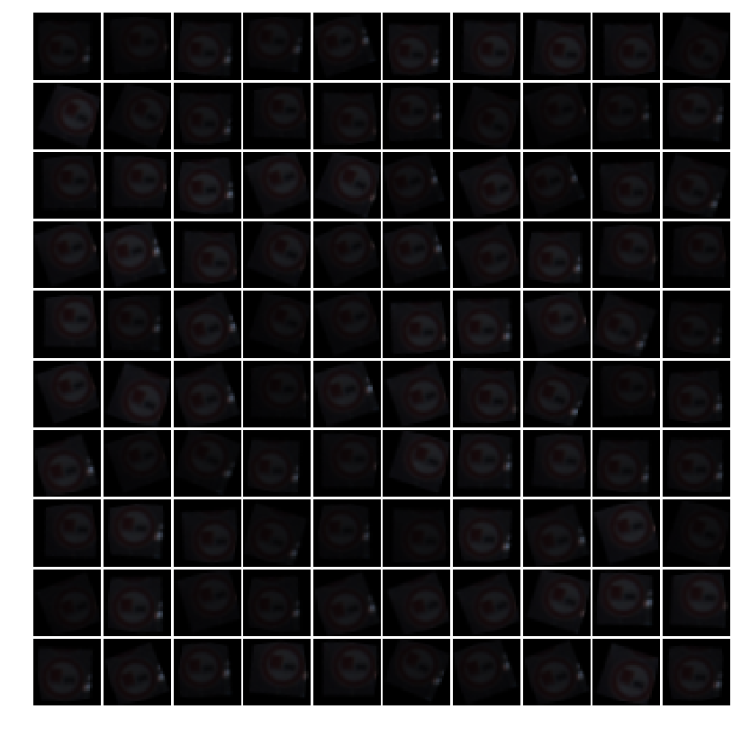

```python
# test augmentation
plot_augmentation_sample()
```

#### Step 2.1.3: Main Data Augmentation Logic

```python
def load_augmented_data(augmented_training_file):

    with open(augmented_training_file, mode='rb') as f:
        augmented_train = pickle.load(f)

    X_data, y_data = augmented_train['features'], augmented_train['labels']

    return X_data, y_data
```

```python
def save_augmented_data(X_data, y_data, augmented_training_file):

    augmented_data = { 'features': X_data, 'labels': y_data }
    with open(augmented_training_file, mode='wb') as f:
        pickle.dump(augmented_data, f, protocol=pickle.HIGHEST_PROTOCOL)
```

```python
def augment_data(X_data, y_data):

    augmented_training_file = 'max_augmented_train.p'
    if isfile(augmented_training_file):
        X_data_large, y_data_large = \
        load_augmented_data(augmented_training_file)
        return X_data_large, y_data_large

    X_data_large = X_data
    y_data_large = y_data

    counts = np.bincount(y_data_large)
    max_count = np.amax(counts)
    below_max = np.where(counts < max_count)[0]

    for class_id in below_max:
        count = counts[class_id]
        new_ratio = int((max_count - count) / count)
        rem = (max_count - count) % count

        class_img_loc = np.where(y_data_large == class_id)[0]
        class_imgs = X_data_large[class_img_loc]

        if new_ratio > 0:
            for img in class_imgs:
                new_imgs = get_more_images(img, new_ratio)
                new_labels = np.full((new_ratio,), class_id)
                X_data_large = np.append(X_data_large, new_imgs, axis=0)
                y_data_large = np.append(y_data_large, new_labels, axis=0)

        for i in range(rem):
            rand_idx = np.random.randint(len(class_imgs))
            img = class_imgs[rand_idx]
            new_imgs = get_more_images(img, 1)
            new_labels = np.full((1,), class_id)
            X_data_large = np.append(X_data_large, new_imgs, axis=0)
            y_data_large = np.append(y_data_large, new_labels, axis=0)

    assert (X_data_large.shape[0] == y_data_large.shape[0]), \
           'Number of features and labels do not match!'

    X_data_large, y_data_large = shuffle(X_data_large, y_data_large)
    save_augmented_data(X_data_large, y_data_large, augmented_training_file)

    return X_data_large, y_data_large
```

### Step 2.2: Pre-process the Data Set (normalization, grayscale, etc.)

Minimally, the image data should be normalized so that the data has mean zero and equal variance. For image data, `(pixel - 128)/ 128` is a quick way to approximately normalize the data and can be used in this project.

Other pre-processing steps are optional. You can try different techniques to see if it improves performance.

Use the code cell (or multiple code cells, if necessary) to implement the first step of your project.

#### Step 2.2.1: Helper Functions for Pre-processing Data

```python
### Preprocess the data here. It is required to normalize the data. Other
### preprocessing steps could include
### converting to grayscale, etc.
### Feel free to use as many code cells as needed.
```

##### **Step 2.2.1.1: Normalize the Image**

```python
def normalize_0_to_1(x):
    """
    Normalize a list of sample image data in the range of 0 to 1
    : x: List of image data.  The image shape is (32, 32, 3) or (32, 32, 1)
    : return: Numpy array of normalize data
    """
    # TODO: Implement Function
    x_min = x.min(axis=(1, 2), keepdims=True)
    x_max = x.max(axis=(1, 2), keepdims=True)
    x = (x - x_min)/(x_max-x_min + 1e-10)
    return x

def normalize_0_mean(x):
    x_mean = np.mean(x)
    x_sd = np.std(x)
    x = (x - x_mean) / x_sd
    return x
```

##### **Step 2.2.1.2: Convert to Grayscale**

```python
def grayscale(img):
    img = cv2.cvtColor(img, cv2.COLOR_RGB2GRAY)
    img = img.reshape(img.shape[0], img.shape[1], 1)
    return img
```

##### **Step 2.2.1.3: Batch Pre-processing on a given Dataset**

```python
def preprocess(X_data):
    new_x = np.zeros((X_data.shape[0], image_shape[0], image_shape[1], 1))
    for index in range(len(X_data)):
        image = X_data[index].squeeze()
        new_x[index] =  normalize_0_to_1(grayscale(image))

    return new_x
```

#### Step 2.2.2: Main Data Pre-processing Logic

```python
# Shuffle
X_train, y_train = shuffle(X_train, y_train)
X_valid, y_valid = shuffle(X_valid, y_valid)
X_test, y_test  = shuffle(X_test, y_test)

# Augment
X_train, y_train = augment_data(X_train, y_train)

# Pre-Process
X_train = preprocess(X_train)
X_valid = preprocess(X_valid)
X_test  = preprocess(X_test)
```

#### Step 2.2.3: Inspect Pre-processed Data

##### **Step 2.2.3.1: Pick a Random Image to Look at**

```
Random image from the Pre-Processed Training set
label: 14 - Stop
```

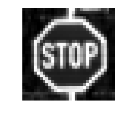

```
Min: 0.000, Max: 1.000, Mean: 0.309, SD: 0.319
```

```python
# Plot a random image
print('Random image from the Pre-Processed Training set')
rnd_idx = plot_random_image(X_train, y_train, signnames)
rnd_img = X_train[rnd_idx].squeeze()
print('Min: {:.3f}, Max: {:.3f}, Mean: {:.3f}, SD: {:.3f}'.format(
      np.amin(rnd_img), np.amax(rnd_img), np.mean(rnd_img), np.std(rnd_img)))
```

##### **Step 2.2.3.2: Look at the First 100 Images of the Training Set**

```
 First 100 images from the Training set
```

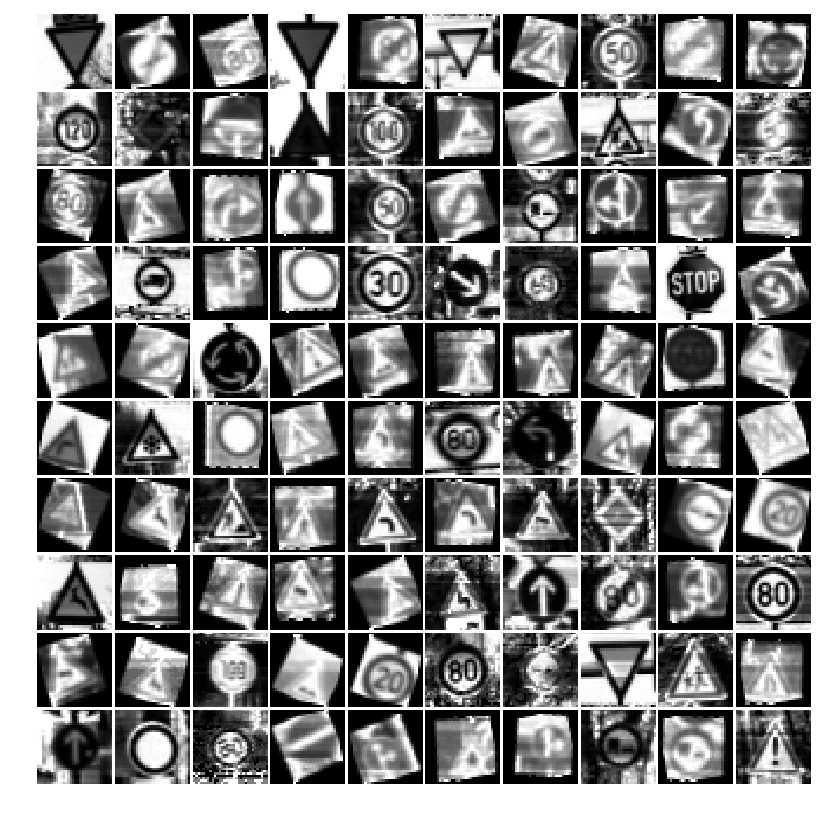

```python
# Plot 1st 100 images in training set
print(' First 100 images from the Training set')
plot_images(X_train[:100], (10, 10), (10, 10), fig_spacing=(0.02, 0.04))
```

##### **Step 2.2.3.2: Look at the First 100 Images of the Validation Set**

```
 First 100 images from the Validation set
```

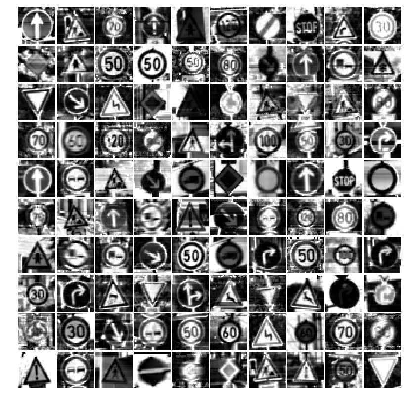

```python
# Plot 1st 100 images in validation set
print(' First 100 images from the Validation set')
plot_images(X_valid[:100], (10, 10), (10, 10), fig_spacing=(0.02, 0.04))
```

##### **Step 2.2.3.3: Observe the Distribution of Classes in the Training Set**

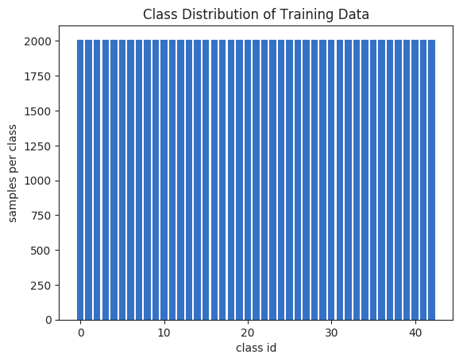

```
Mean: 2010, Min: 2010, Max: 2010, Total: 86430
```

```python
## make a histogram of features and labels in the training set
title = 'Class Distribution of Training Data'
plot_class_id_distribution(y_train, x_label, y_label, title, color='b')
```

### Step 2.3: Model Architecture

```python
### Define your architecture here.
### Feel free to use as many code cells as needed.
```

#### Step 2.3.1: TensorFlow NN Helper Functions

##### **Step 2.3.1.1: Convolutional Layer**

```python
def conv2d(x_tensor, conv_num_outputs, conv_ksize, conv_strides, mu=0, sigma=0.1):
    """
    Apply convolution then max pooling to x
    :param x_tensor: TensorFlow Tensor
    :param conv_num_outputs: Number of outputs for the convolutional layer
    :param conv_ksize: kernal size 2-D Tuple for the convolutional layer
    :param conv_strides: Stride 2-D Tuple for convolution
    :param pool_ksize: kernal size 2-D Tuple for pool
    :param pool_strides: Stride 2-D Tuple for pool
    : return: A tensor that represents convolution and max pooling of x_tensor
    """

    # Weights
    w = tf.Variable(tf.truncated_normal(
        shape=(conv_ksize[0],
               conv_ksize[1],
               x_tensor.get_shape().as_list()[-1],
               conv_num_outputs),
        mean=mu,
        stddev=sigma))

    # Bias
    # b = tf.Variable(tf.zeros(conv_num_outputs))
    b = tf.Variable(tf.truncated_normal(shape=[conv_num_outputs],
                                        mean=mu,
                                        stddev=sigma))

    # Convolutional Layer
    conv = tf.nn.conv2d(x_tensor, w,
                        strides=[1, conv_strides[0], conv_strides[1], 1],
                        padding='SAME')
    # Add Bias
    conv = tf.nn.bias_add(conv, b)

    return conv
```

##### **Step 2.3.1.2: Max Pool Layer**

```python
def maxpool(x_tensor, pool_ksize, pool_strides):
    # Pooling
    conv = tf.nn.max_pool(x_tensor,
                          ksize=[1, pool_ksize[0], pool_ksize[1], 1],
                          strides=[1, pool_strides[0], pool_strides[1], 1],
                          padding='SAME')

    return conv
```

##### **Step 2.3.1.3: Relu Activation Layer**

```python
def relu(x_tensor):
    # Activation.
    return tf.nn.relu(x_tensor)
```

##### **Step 2.3.1.4: Fully Connected Layer**

```python
def fully_connected(x_tensor, num_outputs, mu=0, sigma=0.1):
    """
    Apply a fully connected layer to x_tensor using weight and bias
    : x_tensor: A 2-D tensor where the first dimension is batch size.
    : num_outputs: The number of output that the new tensor should be.
    : return: A 2-D tensor where the second dimension is num_outputs.
    """

    # Weights
    w = tf.Variable(tf.truncated_normal(
        shape=(x_tensor.get_shape().as_list()[1], num_outputs),
        mean = mu,
        stddev = sigma))

    # Bias
    # b = tf.Variable(tf.zeros(num_outputs))
    b = tf.Variable(tf.truncated_normal(shape=[num_outputs],
                                        mean=mu,
                                        stddev=sigma))

    # Fully Connected
    fc = tf.add(tf.matmul(x_tensor, w), b)

    return fc
```

##### **Step 2.3.1.5: Dropout Layer**

```python
def drop_out(x_tensor, keep_prob):
    drop = tf.nn.dropout(x_tensor, keep_prob)
    return drop
```

#### Step 2.3.2: Main Network Definition

```python
def SriNet(x, keep_prob):

    conv1 = conv2d(x, 64, (4, 4), (1, 1))
    conv1 = relu(conv1)

    conv2 = conv2d(conv1, 128, (4, 4), (1, 1))
    conv2 = relu(conv2)
    conv2 = maxpool(conv2, (2, 2), (2, 2))
    conv2 = drop_out(conv2, keep_prob)

    conv3 = conv2d(conv2, 256, (4, 4), (1, 1))
    conv3 = relu(conv3)
    conv3 = maxpool(conv3, (2, 2), (2, 2))
    conv3 = drop_out(conv3, keep_prob)

    fc0 = flatten(conv3)

    fc1 = fully_connected(fc0, 1024)
    fc1 = relu(fc1)
    fc1 = drop_out(fc1, keep_prob)

    fc2 = fully_connected(fc1, 512)
    fc2 = relu(fc2)
    fc2 = drop_out(fc2, keep_prob)

    logits = fully_connected(fc2, n_classes)

    return logits
```

#### Step 2.3.3: TensorFlow Placeholders

```python
# Placeholders

processed_image_shape = X_train[0].shape
input_shape = [None] + list(processed_image_shape)

tf.reset_default_graph()

x = tf.placeholder(tf.float32, input_shape)
y = tf.placeholder(tf.int32, (None))
keep_prob = tf.placeholder(tf.float32, shape=None)
one_hot_y = tf.one_hot(y, n_classes)
```

#### Step 2.3.4: Model Hyper-parameters

```python
# Hyperparameters

EPOCHS = 15
BATCH_SIZE = 64
rate = 0.00075
keep_probability = 0.75
```

#### Step 2.3.5: Define Logits, Cross Entropy, Cost and Optimizer

```python
# NN Definitions

logits = SriNet(x, keep_prob)
cross_entropy = tf.nn.softmax_cross_entropy_with_logits(labels=one_hot_y,
                                                        logits=logits)
cost = tf.reduce_mean(cross_entropy)
optimizer = tf.train.AdamOptimizer(learning_rate = rate)
training_operation = optimizer.minimize(cost)
```

### Step 2.4: Train, Validate and Test the Model

A validation set can be used to assess how well the model is performing. A low accuracy on the training and validation sets imply underfitting. A high accuracy on the training set but low accuracy on the validation set implies overfitting.

```python
### Train your model here.
### Calculate and report the accuracy on the training and validation set.
### Once a final model architecture is selected,
### the accuracy on the test set should be calculated and reported as well.
### Feel free to use as many code cells as needed.
```

#### Step 2.4.1: Validation and Test Function

```python
correct_prediction = tf.equal(tf.argmax(logits, 1), tf.argmax(one_hot_y, 1))
accuracy_operation = tf.reduce_mean(tf.cast(correct_prediction, tf.float32))
saver = tf.train.Saver()


def evaluate(X_data, y_data):
    num_examples = len(X_data)
    total_accuracy = 0
    sess = tf.get_default_session()
    for offset in range(0, num_examples, BATCH_SIZE):
        batch_x, batch_y = X_data[offset:offset + BATCH_SIZE], \
                           y_data[offset:offset + BATCH_SIZE]
        accuracy = sess.run(accuracy_operation,
                            feed_dict={x: batch_x,
                                       y: batch_y,
                                       keep_prob: 1.0})
        total_accuracy += (accuracy * len(batch_x))
    return total_accuracy / num_examples
```

#### Step 2.4.2: Train the Model

```python
with tf.Session() as sess:
    sess.run(tf.global_variables_initializer())
    num_examples = len(X_train)

    print("Training...")
    print()
    for i in range(EPOCHS):
        X_train, y_train = shuffle(X_train, y_train)
        for offset in range(0, num_examples, BATCH_SIZE):
            end = offset + BATCH_SIZE
            batch_x, batch_y = X_train[offset:end], y_train[offset:end]
            sess.run(training_operation,
                     feed_dict={x: batch_x, y: batch_y,
                                keep_prob: keep_probability})

        validation_accuracy = evaluate(X_valid, y_valid)
        print("EPOCH {} ...".format(i+1))
        print("Validation Accuracy = {:.3f}".format(validation_accuracy))
        print()

    saver.save(sess, './checkpoints/srinet.ckpt')
    print("Model saved")
```

```
Training...

EPOCH 1 ...
Validation Accuracy = 0.846

EPOCH 2 ...
Validation Accuracy = 0.953

EPOCH 3 ...
Validation Accuracy = 0.972

EPOCH 4 ...
Validation Accuracy = 0.977

EPOCH 5 ...
Validation Accuracy = 0.969

EPOCH 6 ...
Validation Accuracy = 0.982

EPOCH 7 ...
Validation Accuracy = 0.981

EPOCH 8 ...
Validation Accuracy = 0.978

EPOCH 9 ...
Validation Accuracy = 0.980

EPOCH 10 ...
Validation Accuracy = 0.974

EPOCH 11 ...
Validation Accuracy = 0.977

EPOCH 12 ...
Validation Accuracy = 0.986

EPOCH 13 ...
Validation Accuracy = 0.986

EPOCH 14 ...
Validation Accuracy = 0.980

EPOCH 15 ...
Validation Accuracy = 0.984

Model saved
```

#### Step 2.4.3: Test the Model

```python
with tf.Session() as sess:
    saver.restore(sess, tf.train.latest_checkpoint('checkpoints'))

    test_accuracy = evaluate(X_test, y_test)
    print("Test Accuracy = {:.3f}".format(test_accuracy))
```

```
Test Accuracy = 0.976
```

## Step 3: Test a Model on New Images

To give yourself more insight into how your model is working, download at least five pictures of German traffic signs from the web and use your model to predict the traffic sign type.

You may find `signnames.csv` useful as it contains mappings from the class id (integer) to the actual sign name.

### Step 3.1: Load and Output the Images

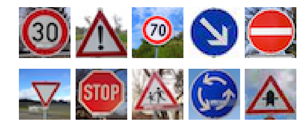

```python
### Load the images and plot them here.
### Feel free to use as many code cells as needed.

image_ls = glob.glob('German_Traffic_Signs_Google/cropped_resized/*.jpg')
test_images = []
for img in image_ls:
    test_images.append(mpimg.imread(img))

test_images = np.asarray(test_images)
plot_images(test_images, (2, 5), (7, 3), fig_spacing=(0.1, 0.1))
```

### Step 3.2: Predict the Sign Type for Each Image

```python
# From signnames.csv
# 1,Speed limit (30km/h)
# 4,Speed limit (70km/h)
# 11,Right-of-way at the next intersection
# 13,Yield
# 14,Stop
# 17,No entry
# 18,General caution
# 25,Road work
# 28,Children crossing
# 38,Keep right
# 40,Roundabout mandatory

test_labels = np.array([1, 18, 4, 38, 17,
                        13, 14, 28, 40, 11])
test_images = preprocess(test_images)
```

```python
### Run the predictions here and use the model to output the prediction
### for each image.
### Make sure to pre-process the images with the same pre-processing pipeline
### used earlier.
### Feel free to use as many code cells as needed.

with tf.Session() as sess:
    saver.restore(sess, tf.train.latest_checkpoint('checkpoints'))

    test_accuracy = evaluate(test_images, test_labels)
    print("Test Accuracy = {:.3f}".format(test_accuracy))
```

```
Test Accuracy = 0.900
```

### Step 3.3: Analyze Performance

```python
### Calculate the accuracy for these 5 new images.
### For example, if the model predicted 1 out of 5 signs correctly,
### it's 20% accurate on these new images.
```

I used the `evaluate` function to get the accuracy on the test images. Accuracy is printed above at the end of Step 3.2

### Step 3.4: Output Top 5 Softmax Probabilities For Each Image Found on the Web

For each of the new images, print out the model's softmax probabilities to show the **certainty** of the model's predictions (limit the output to the top 5 probabilities for each image). [`tf.nn.top_k`](https://www.tensorflow.org/versions/r0.12/api_docs/python/nn.html#top_k) could prove helpful here.

The example below demonstrates how tf.nn.top_k can be used to find the top k predictions for each image.

`tf.nn.top_k` will return the values and indices (class ids) of the top k predictions. So if k=3, for each sign, it'll return the 3 largest probabilities (out of a possible 43) and the correspoding class ids.

Take this numpy array as an example. The values in the array represent predictions. The array contains softmax probabilities for five candidate images with six possible classes. `tk.nn.top_k` is used to choose the three classes with the highest probability:

```
# (5, 6) array
a = np.array([[ 0.24879643,  0.07032244,  0.12641572,  0.34763842,  0.07893497,
         0.12789202],
       [ 0.28086119,  0.27569815,  0.08594638,  0.0178669 ,  0.18063401,
         0.15899337],
       [ 0.26076848,  0.23664738,  0.08020603,  0.07001922,  0.1134371 ,
         0.23892179],
       [ 0.11943333,  0.29198961,  0.02605103,  0.26234032,  0.1351348 ,
         0.16505091],
       [ 0.09561176,  0.34396535,  0.0643941 ,  0.16240774,  0.24206137,
         0.09155967]])
```

Running it through `sess.run(tf.nn.top_k(tf.constant(a), k=3))` produces:

```
TopKV2(values=array([[ 0.34763842,  0.24879643,  0.12789202],
       [ 0.28086119,  0.27569815,  0.18063401],
       [ 0.26076848,  0.23892179,  0.23664738],
       [ 0.29198961,  0.26234032,  0.16505091],
       [ 0.34396535,  0.24206137,  0.16240774]]), indices=array([[3, 0, 5],
       [0, 1, 4],
       [0, 5, 1],
       [1, 3, 5],
       [1, 4, 3]], dtype=int32))
```

Looking just at the first row we get `[ 0.34763842, 0.24879643, 0.12789202]`, you can confirm these are the 3 largest probabilities in `a`. You'll also notice `[3, 0, 5]` are the corresponding indices.

```python
### Print out the top five softmax probabilities for the predictions on the
### German traffic sign images found on the web.
### Feel free to use as many code cells as needed.

softmax_operation = tf.nn.softmax(logits)
top_k = 5

with tf.Session() as sess:
    saver.restore(sess, tf.train.latest_checkpoint('checkpoints'))
    softmax_output = sess.run(softmax_operation,
                              feed_dict={x: test_images,
                                         y: test_labels,
                                         keep_prob: 1.0})

with tf.Session() as sess:
    top_k_probs = sess.run(tf.nn.top_k(tf.constant(softmax_output), k=top_k))
```

```python
for i in range(len(test_labels)):
    actual = signnames[str(test_labels[i])]
    prediction = signnames[str(top_k_probs[1][i, 0])]
    print('\n{}. Actual: {}, Prediction: {}'.format(i+1, actual, prediction))
    print('Top {} Probabilities:'.format(top_k))
    for j in range(top_k):
        class_id = signnames[str(top_k_probs[1][i, j])]
        print('{}. {}: {:.3f}'. \
              format(j+1, class_id, top_k_probs[0][i, j]))
```

```
1. Actual: Speed limit (30km/h), Prediction: Speed limit (30km/h)
Top 5 Probabilities:
1. Speed limit (30km/h): 1.000
2. Speed limit (50km/h): 0.000
3. Speed limit (20km/h): 0.000
4. Speed limit (80km/h): 0.000
5. Speed limit (70km/h): 0.000

2. Actual: General caution, Prediction: General caution
Top 5 Probabilities:
1. General caution: 1.000
2. Bicycles crossing: 0.000
3. Traffic signals: 0.000
4. Children crossing: 0.000
5. Pedestrians: 0.000

3. Actual: Speed limit (70km/h), Prediction: Speed limit (70km/h)
Top 5 Probabilities:
1. Speed limit (70km/h): 1.000
2. Speed limit (20km/h): 0.000
3. Speed limit (30km/h): 0.000
4. Speed limit (120km/h): 0.000
5. Road narrows on the right: 0.000

4. Actual: Keep right, Prediction: Keep right
Top 5 Probabilities:
1. Keep right: 1.000
2. Roundabout mandatory: 0.000
3. Speed limit (30km/h): 0.000
4. Turn left ahead: 0.000
5. Speed limit (20km/h): 0.000

5. Actual: No entry, Prediction: No entry
Top 5 Probabilities:
1. No entry: 1.000
2. End of all speed and passing limits: 0.000
3. Speed limit (80km/h): 0.000
4. Keep right: 0.000
5. Stop: 0.000

```

[output cut: 24 more lines]

```
9. Actual: Roundabout mandatory, Prediction: Turn right ahead
Top 5 Probabilities:
1. Turn right ahead: 0.640
2. Stop: 0.341
3. Keep left: 0.008
4. No entry: 0.007
5. Roundabout mandatory: 0.001

10. Actual: Right-of-way at the next intersection, Prediction: Right-of-way at the next intersection
Top 5 Probabilities:
1. Right-of-way at the next intersection: 1.000
2. Beware of ice/snow: 0.000
3. Double curve: 0.000
4. Pedestrians: 0.000
5. End of speed limit (80km/h): 0.000
```

## Step 4: Project Writeup

Once you have completed the code implementation, document your results in a project writeup using this [template](https://github.com/udacity/CarND-Traffic-Sign-Classifier-Project/blob/master/writeup_template.md) as a guide. The writeup can be in a markdown or pdf file.

## Step 5 (Optional): Visualize the Neural Network's State with Test Images

This Section is not required to complete but acts as an additional excersise for understaning the output of a neural network's weights. While neural networks can be a great learning device they are often referred to as a black box. We can understand what the weights of a neural network look like better by plotting their feature maps. After successfully training your neural network you can see what it's feature maps look like by plotting the output of the network's weight layers in response to a test stimuli image. From these plotted feature maps, it's possible to see what characteristics of an image the network finds interesting. For a sign, maybe the inner network feature maps react with high activation to the sign's boundary outline or to the contrast in the sign's painted symbol.

Provided for you below is the function code that allows you to get the visualization output of any tensorflow weight layer you want. The inputs to the function should be a stimuli image, one used during training or a new one you provided, and then the tensorflow variable name that represents the layer's state during the training process, for instance if you wanted to see what the LeNet lab's feature maps looked like for it's second convolutional layer you could enter conv2 as the tf_activation variable.

For an example of what feature map outputs look like, check out NVIDIA's results in their paper [End-to-End Deep Learning for Self-Driving Cars](https://devblogs.nvidia.com/parallelforall/deep-learning-self-driving-cars/) in the section Visualization of internal CNN State. NVIDIA was able to show that their network's inner weights had high activations to road boundary lines by comparing feature maps from an image with a clear path to one without. Try experimenting with a similar test to show that your trained network's weights are looking for interesting features, whether it's looking at differences in feature maps from images with or without a sign, or even what feature maps look like in a trained network vs a completely untrained one on the same sign image.

[figure not shown]

Your output should look something like this (above)

```python
### Visualize your network's feature maps here.
### Feel free to use as many code cells as needed.

# image_input: the test image being fed into the network to produce the feature maps
# tf_activation: should be a tf variable name used during your training procedure that represents the calculated state of a specific weight layer
# activation_min/max: can be used to view the activation contrast in more detail, by default matplot sets min and max to the actual min and max values of the output
# plt_num: used to plot out multiple different weight feature map sets on the same block, just extend the plt number for each new feature map entry

def outputFeatureMap(image_input, tf_activation, activation_min=-1, activation_max=-1 ,plt_num=1):
    # Here make sure to preprocess your image_input in a way your network expects
    # with size, normalization, ect if needed
    # image_input =
    # Note: x should be the same name as your network's tensorflow data placeholder variable
    # If you get an error tf_activation is not defined it may be having trouble accessing the variable from inside a function
    activation = tf_activation.eval(session=sess,feed_dict={x : image_input})
    featuremaps = activation.shape[3]
    plt.figure(plt_num, figsize=(15,15))
    for featuremap in range(featuremaps):
        plt.subplot(6,8, featuremap+1) # sets the number of feature maps to show on each row and column
        plt.title('FeatureMap ' + str(featuremap)) # displays the feature map number
        if activation_min != -1 & activation_max != -1:
            plt.imshow(activation[0,:,:, featuremap], interpolation="nearest", vmin =activation_min, vmax=activation_max, cmap="gray")
        elif activation_max != -1:
            plt.imshow(activation[0,:,:, featuremap], interpolation="nearest", vmax=activation_max, cmap="gray")
        elif activation_min !=-1:
            plt.imshow(activation[0,:,:, featuremap], interpolation="nearest", vmin=activation_min, cmap="gray")
        else:
            plt.imshow(activation[0,:,:, featuremap], interpolation="nearest", cmap="gray")
```